# 06-exercises

Octavio Suarez Munist

2016-05-18

## Reading: - **APM** Chapter 8.6 and 8.8 - **APM** Chapter 14.8 - **APM** Chapter 7.1 & 7.3 “Non-Linear Regression Models” - **APM** Chapter 13.2 & 13.4 “Non-Linear Classifcation Models”

## Fuel Economy

This week we return to the Fuel Economy Data having learned much about model building. This assignment is to go through the process of building several regression models and pick the most predictive model. Use the `FE` data set created for you above.

Start by making choosing a metric and making a naive guess of model performance:

Metric: **RMSE *Naive Guess:*** *34.71* __________ Expected Model Performance (based on Naive Guess): _____11.31_______

Show your work below for the calculations

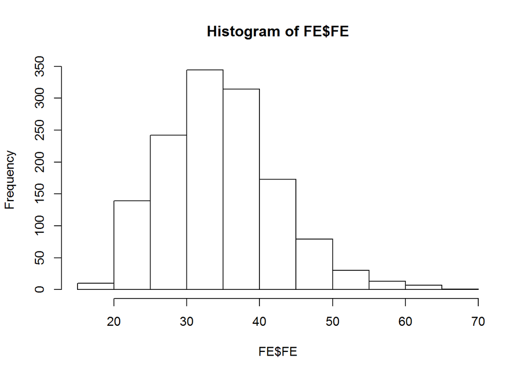

```r
naive_guess = mean(FE$FE)

err_naive_guess = RMSE(FE12$FE,rep(34.71,nrow(FE12)))

hist(FE$FE)
```

Based only on your intuition, how low do your think you can get your metric: *Lookign at the histogram, the distribution looks normal, with some skewness. That, combined with the high predictablility of physics and engineering (versus human behavior, for example) mkaes me think this can belowqeed significanlty, to between 2 and 3 MPG.* __

## Examine your data

Scatter plot to look at EngDisp vs. NumCyl so I can select my predictor guess:

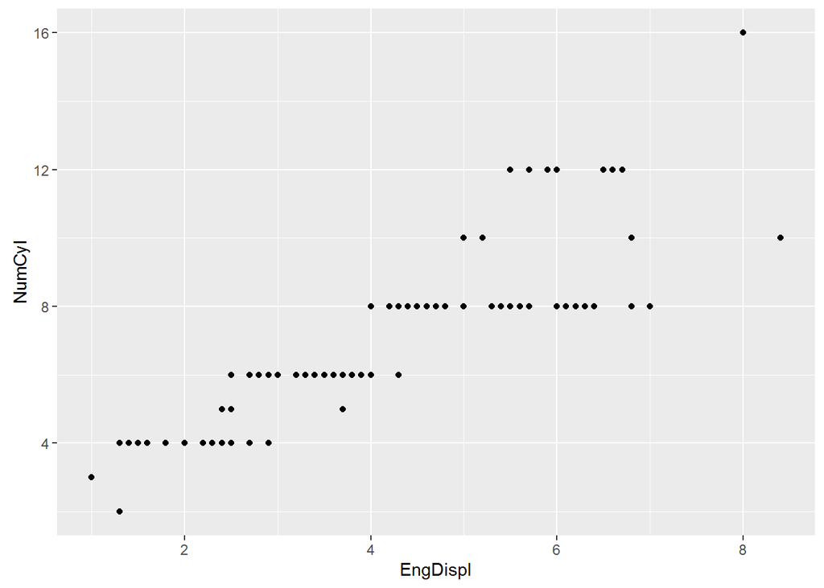

```r
ggplot(FE,aes(EngDispl,NumCyl)) + geom_point()
```

NumCyl would be my choice, but EngDispl is more continuous.Cleary, they do correlate highly. * Plot your response/outcome

- Make a guess of a strong predictor: _____EngDispl____
- Plot your response vs your predictor.

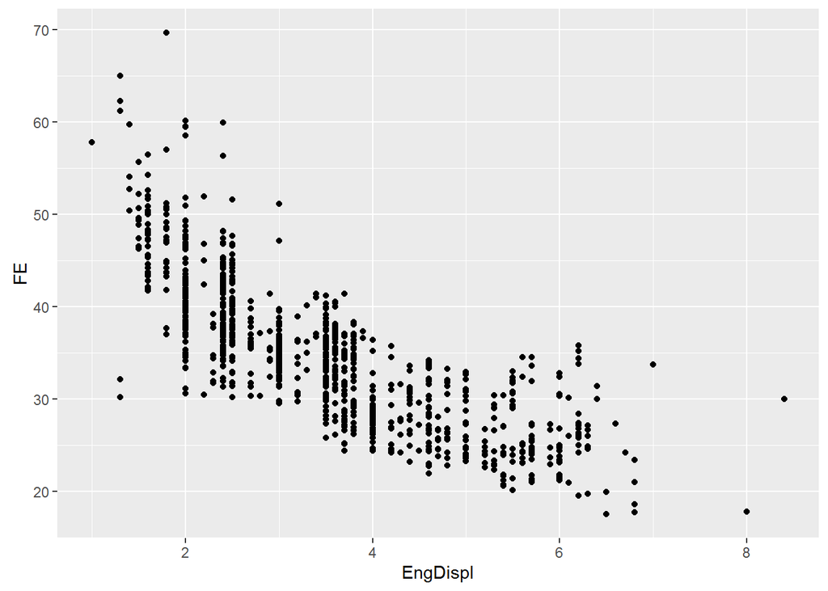

```r
ggplot(FE,aes(EngDispl,FE)) + geom_point()
```

## Build Simple Models

Using **caret**, build a simple linear model and a simple tree model.

```r
ctrl <- trainControl( method="boot", number=5, savePrediction=TRUE )

fit.lm <- train(FE ~ EngDispl, data=FE, method="glm", trControl=ctrl)
rmse.lm <- RMSE(predict(fit.lm, FE12),FE12$FE)

fit.rp <- train(FE ~ EngDispl, data=FE, method="rpart",trControl=ctrl, tuneLength=20)
rmse.rp <- RMSE(predict(fit.rp, FE12),FE12$FE)
```

What did you learn about the data from these models.

Both reduced the RMSE significantly (44% and 55%, respectively), but still far from my estimate.

## Build More Advanced Models

Now refine your models. Use **caret** to build advanced models: - one that uses model averaging (bagging) - one that uses boosting

## Conclusion

Which model would you use and why? Under different circumstances why would you choose one of the other models.